# Silicon Benchmark Forecast Diagnostics

Team 16 — internal interpretation report

August 24, 2026

# 1 Executive summary

This report summarizes **internal forecast behavior**, not predictive accuracy. The benchmark outcomes remain unknown, so correlations and agreement can reveal stability or shared assumptions but cannot establish that a model is correct.

> The present files contain **8 models** and **2 prompt variants**. Model-level values are aggregated before the models receive equal weight.
- Coverage: **208 of 208 intervention–outcome cells**.
- Models represented: **8**.
- Fixed prompt variants represented: **2**.
- Median absolute candidate effect: **1.25% of the outcome scale**.
- Largest absolute candidate effect: **4.00% of the outcome scale**.
- Directional balance: **191 positive**, **17 negative**, and **0 exactly zero** forecasts.
- Median prompt-to-prompt range: **0.32% of the outcome scale**; maximum: **25.00%**.

# 2 Run contents and completeness

Configured settings for models represented in the report

| Item | Value |
| --- | --- |
| Models in derived files | 8 |
| Prompt variants | 2 |
| Interventions | 16 |
| Outcomes | 13 |
| Unique intervention-outcome cells | 208 |
| Expected intervention-outcome cells | 208 |
| Missing numeric forecasts | 0 |

| model_id | model | family | temperature | output_mode | n_completions | roster_status |
| --- | --- | --- | --- | --- | --- | --- |
| gemini-3.1-pro-preview | gemini-3.1-pro-preview | Google | 0 | structured | 1 | preferred |
| gemini-2.5-pro | gemini-2.5-pro | Google | 0 | structured | 1 | fallback |
| claude-opus-4-6 | anthropic.claude-opus-4-6 | Anthropic | 0 | structured | 1 | preferred |
| claude-haiku-4-5 | anthropic.claude-haiku-4-5@20251001 | Anthropic | 0 | structured | 1 | diagnostic |
| gpt-5-mini | @gpt-5-mini/gpt-5-mini | OpenAI | 1 | structured | 5 | preferred |
| gpt-4o-mini | @gpt-4o-mini-c6f977/gpt-4o-mini | OpenAI | 0 | structured | 1 | diagnostic |
| gemini-2.5-flash-lite | gemini-2.5-flash-lite | Google | 0 | structured | 1 | validation |
| gemini-3.1-flash-lite | gemini-3.1-flash-lite | Google | 0 | structured | 1 | diagnostic |

# 3 Candidate consensus forecast map

This figure shows the primary provisional consensus from the three preselected family representatives. For every intervention and outcome, repeated completions are combined within prompts, prompts within models, and finally the 3 represented model families receive equal weight. Medians are used at every step to reduce the influence of an unusually extreme forecast.

**What is an average treatment effect (ATE)?**  
An ATE is the predicted average outcome in the intervention group minus the predicted average in the control group. For example, this study includes an actual `donation_ams` outcome ranging from $0 to $10. An ATE of $1 would mean that participants receiving the intervention are forecast to donate one dollar more, on average, than participants reading a neutral control text. On the normalized heatmap that equals 10% of the donation scale. Similarly, a 5-point ATE on a 0–100 outcome equals 5% of its scale, while an ATE of 0.05 for the binary newsletter-signup outcome means a five-percentage-point difference. The sign matters: a negative ATE means the intervention group is forecast to score lower than the control group, which can be desirable for an outcome such as distrust.

Preselected models contributing to the primary provisional consensus

| family | n_models | models |
| --- | --- | --- |
| Anthropic | 1 | claude-opus-4-6 |
| Google | 1 | gemini-3.1-pro-preview |
| OpenAI | 1 | gpt-5-mini |

Each tile expresses the consensus ATE as a fraction of that outcome’s possible range. The map is useful for seeing direction and relative magnitude across the complete intervention-by-outcome grid, spotting unexpectedly extreme cells, and checking whether substantive patterns are coherent. It does not show predictive accuracy because the human benchmark results remain hidden.

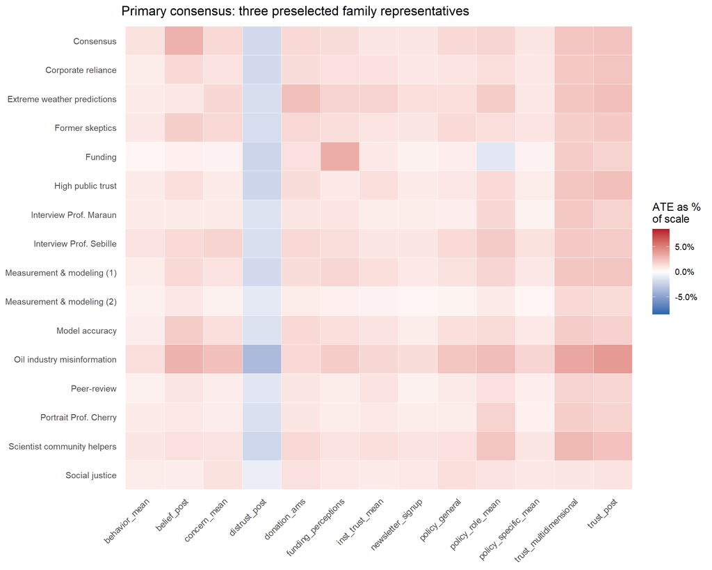

## 3.1 All-model diagnostic sensitivity map

This second map repeats the same hierarchical median rule using all 8 models with complete full-run results. Models are still combined within their developer families before the 3 families receive equal weight, so a family does not gain extra final weight merely because more variants were tested. This map is diagnostic only: it asks whether broadening the model roster materially changes the pattern of forecasts. Both maps use the same color scale, so their colors can be compared directly.

All completed models contributing to the diagnostic sensitivity map

| family | n_models | models |
| --- | --- | --- |
| Anthropic | 2 | claude-haiku-4-5, claude-opus-4-6 |
| Google | 4 | gemini-2.5-flash-lite, gemini-2.5-pro, gemini-3.1-flash-lite, gemini-3.1-pro-preview |
| OpenAI | 2 | gpt-4o-mini, gpt-5-mini |

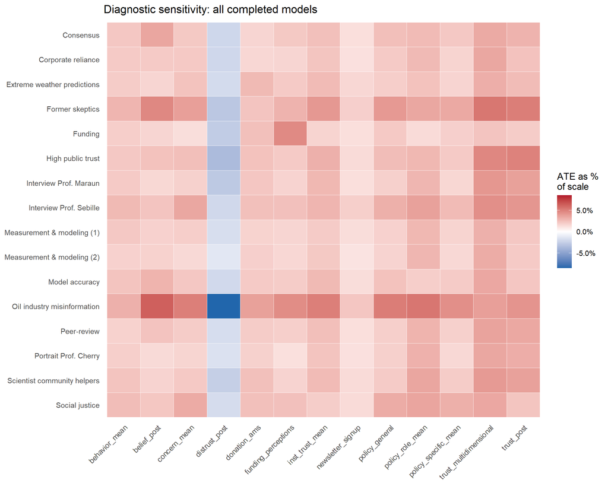

Across the 208 cells, the median absolute difference between the primary and all-model consensuses is **1.12% of the outcome scale**; the largest difference is **4.90%**.

## 3.2 Largest positive and negative forecasts

These are useful for checking face validity and scale interpretation. They are not evidence that the corresponding interventions will produce the largest human effects.

Largest absolute candidate effects after normalizing by outcome range

| direction | condition | outcome | ate | scale_percent |
| --- | --- | --- | --- | --- |
| Negative | Oil industry misinformation | distrust_post | -3.60 | -3.60 |
| Negative | Funding | distrust_post | -2.20 | -2.20 |
| Negative | High public trust | distrust_post | -2.15 | -2.15 |
| Negative | Scientist community helpers | distrust_post | -2.10 | -2.10 |
| Negative | Consensus | distrust_post | -1.90 | -1.90 |
| Negative | Corporate reliance | distrust_post | -1.90 | -1.90 |
| Negative | Measurement & modeling (1) | distrust_post | -1.90 | -1.90 |
| Negative | Former skeptics | distrust_post | -1.75 | -1.75 |
| Positive | Oil industry misinformation | trust_post | 4.00 | 4.00 |
| Positive | Oil industry misinformation | trust_multidimensional | 3.50 | 3.50 |
| Positive | Funding | funding_perceptions | 3.25 | 3.25 |
| Positive | Consensus | belief_post | 3.00 | 3.00 |
| Positive | Oil industry misinformation | belief_post | 3.00 | 3.00 |
| Positive | Scientist community helpers | trust_multidimensional | 2.75 | 2.75 |
| Positive | Oil industry misinformation | policy_role_mean | 2.60 | 2.60 |
| Positive | High public trust | trust_post | 2.55 | 2.55 |

# 4 Outcome-level calibration

This figure asks whether the forecasting ensemble systematically assigns larger effects to some outcomes than others after accounting for their different native scales. Outcomes are sorted by the median absolute consensus effect, with the largest typical effects at the top.

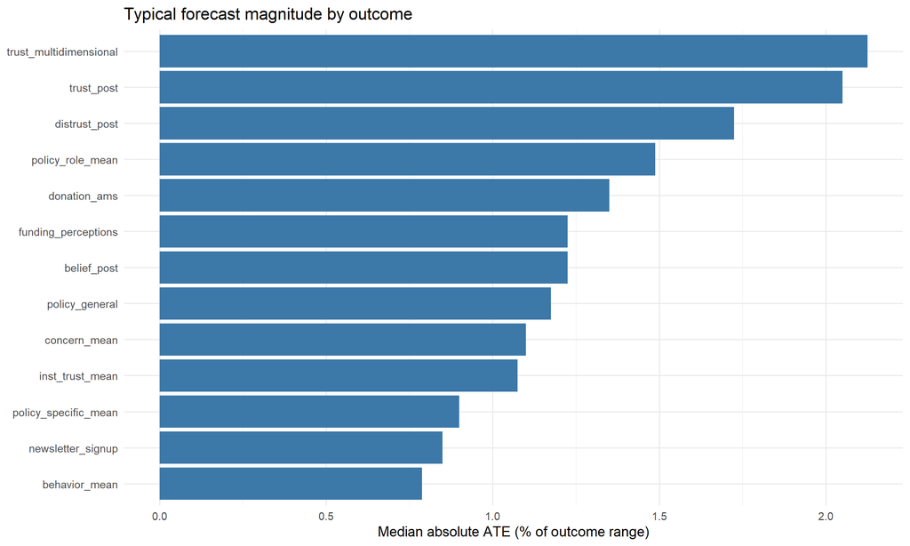

# 5 Primary median versus Nalanda mean sensitivity

The locked candidate uses Nalanda’s native median at each level for robustness. The sensitivity analysis reruns the same equal-weight hierarchy with arithmetic means across completions, prompts, models, and families. The comparison below shows whether that reducer choice materially changes the forecasts.

- Median absolute method difference: **0.08% of the outcome scale**.
- Maximum absolute method difference: **0.70% of the outcome scale**.

Cells most affected by median versus arithmetic-mean aggregation

| condition | outcome | median_hierarchy_ate | mean_hierarchy_ate | mean_minus_median_scale_percent |
| --- | --- | --- | --- | --- |
| Funding | policy_role_mean | -1.25 | -0.550 | 0.700 |
| Funding | funding_perceptions | 3.25 | 3.867 | 0.617 |
| Model accuracy | distrust_post | -1.50 | -1.927 | -0.427 |
| Model accuracy | trust_post | 1.80 | 2.187 | 0.387 |
| Interview Prof. Sebille | newsletter_signup | 0.01 | 0.014 | 0.373 |
| Consensus | belief_post | 3.00 | 3.367 | 0.367 |
| Oil industry misinformation | trust_post | 4.00 | 3.670 | -0.330 |
| Extreme weather predictions | distrust_post | -1.70 | -2.010 | -0.310 |
| Oil industry misinformation | donation_ams | 0.15 | 0.181 | 0.307 |
| Peer-review | distrust_post | -1.30 | -1.593 | -0.293 |
| Peer-review | trust_post | 1.60 | 1.885 | 0.285 |
| High public trust | trust_multidimensional | 2.30 | 2.027 | -0.273 |

# 6 Prompt robustness

Prompt agreement tests whether fixed wording variants elicit similar forecasts from the same model. Strong agreement is desirable for stability, but two prompts can agree and still share the same bias.

Prompt-variant agreement across the 208 cells

| forecast_model | pearson | spearman |
| --- | --- | --- |
| claude-haiku-4-5 | 0.814 | 0.755 |
| claude-opus-4-6 | 0.910 | 0.779 |
| gemini-2.5-flash-lite | 0.734 | 0.626 |
| gemini-2.5-pro | 0.923 | 0.844 |
| gemini-3.1-flash-lite | 0.887 | 0.777 |
| gemini-3.1-pro-preview | 0.933 | 0.885 |
| gpt-4o-mini | 0.648 | 0.512 |
| gpt-5-mini | 0.904 | 0.798 |

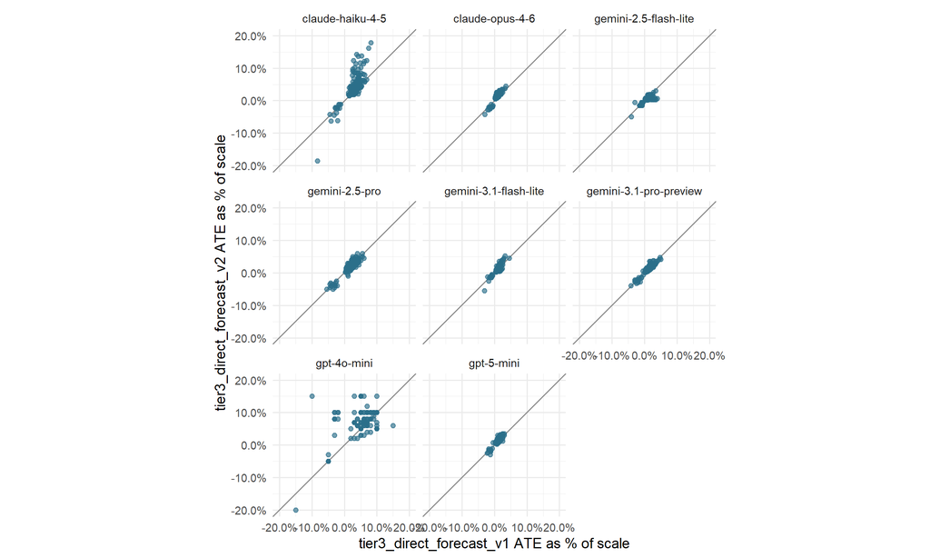

## 6.1 Cells most sensitive to prompt wording

All models with complete full-run results are included below. A model can look absent for a particular outcome when its median prompt gap is exactly zero: a zero-height bar is invisible. The statistic is the median, across interventions, of the absolute gap between the two fixed prompt variants for each outcome and model. It measures prompt sensitivity, not forecast magnitude or accuracy.

Largest within-model prompt ranges

| forecast_model | condition | outcome | n_prompts | prompt_range_percent |
| --- | --- | --- | --- | --- |
| gpt-4o-mini | Oil industry misinformation | trust_post | 2 | 25.0 |
| gpt-4o-mini | Extreme weather predictions | trust_post | 2 | 13.0 |
| gpt-4o-mini | Social justice | trust_post | 2 | 13.0 |
| gpt-4o-mini | Consensus | trust_post | 2 | 12.0 |
| gpt-4o-mini | Oil industry misinformation | inst_trust_mean | 2 | 12.0 |
| gpt-4o-mini | Oil industry misinformation | trust_multidimensional | 2 | 12.0 |
| gpt-4o-mini | Measurement & modeling (1) | trust_post | 2 | 11.0 |
| gpt-4o-mini | Measurement & modeling (2) | trust_post | 2 | 11.0 |
| gpt-4o-mini | Model accuracy | trust_post | 2 | 11.0 |
| claude-haiku-4-5 | Former skeptics | trust_post | 2 | 10.4 |
| claude-haiku-4-5 | Oil industry misinformation | distrust_post | 2 | 10.2 |
| gpt-4o-mini | Corporate reliance | trust_post | 2 | 10.0 |
| gpt-4o-mini | Extreme weather predictions | funding_perceptions | 2 | 10.0 |
| gpt-4o-mini | Interview Prof. Sebille | funding_perceptions | 2 | 10.0 |
| gpt-4o-mini | Social justice | funding_perceptions | 2 | 10.0 |

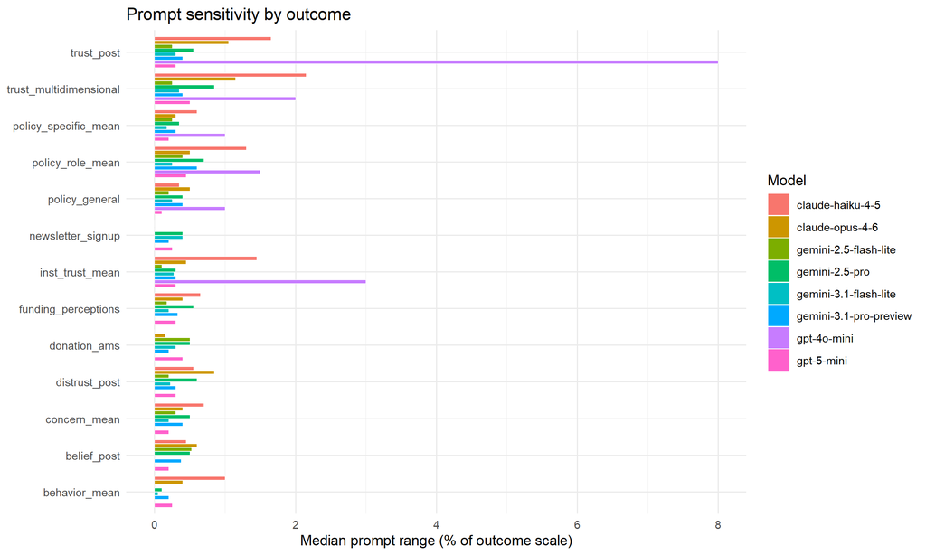

**Largest current prompt signal:** gpt-4o-mini has the largest model–outcome median prompt gap: 8.0% of the outcome scale for `trust_post`. This is a stability warning: the two fixed prompt formulations produce materially different forecasts for that model. It does not, by itself, reveal which forecast or model is more accurate.

# 7 Model agreement

Overall scale-normalized model agreement

| metric | value | interpretation | n_models | n_units | p_value |
| --- | --- | --- | --- | --- | --- |
| icc | 0.296 | poor | 8 | 208 | 0 |
| kendall_w | 0.653 | moderate | 8 | 208 | 0 |

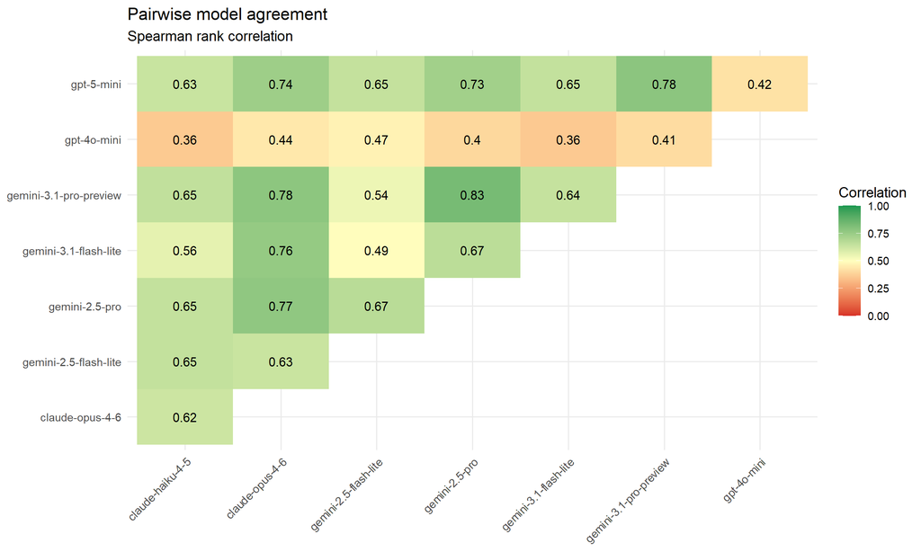

Cells with the largest cross-model range

| condition | outcome | model_range_percent |
| --- | --- | --- |
| Oil industry misinformation | distrust_post | 15.15 |
| Oil industry misinformation | belief_post | 10.60 |
| Oil industry misinformation | trust_post | 10.45 |
| Social justice | donation_ams | 9.80 |
| Extreme weather predictions | funding_perceptions | 9.60 |
| Extreme weather predictions | belief_post | 9.53 |
| Portrait Prof. Cherry | donation_ams | 9.50 |
| Social justice | policy_specific_mean | 9.50 |
| Interview Prof. Maraun | belief_post | 9.45 |
| Social justice | belief_post | 9.45 |
| Corporate reliance | belief_post | 9.43 |
| Interview Prof. Sebille | funding_perceptions | 9.40 |
| Measurement & modeling (2) | belief_post | 9.40 |
| Portrait Prof. Cherry | belief_post | 9.38 |
| High public trust | belief_post | 9.35 |

# 8 Interpretation checklist

Use this report to discuss the following questions with collaborators:

1. Do the largest positive and negative forecasts make substantive sense given the interventions and outcome directions?
2. Are any outcomes consistently assigned much larger effects than others after accounting for their native scales?
3. Which cells are sensitive to prompt wording, and are those disagreements large enough to justify another fixed prompt variant?
4. Once several models are present, do disagreements reflect magnitude, direction, or both?
5. Are any routing failures, missing cells, or manual repairs present? If yes, do not lock a submission until they are resolved and documented.

## 8.1 What this report cannot establish

- It cannot identify the most accurate model without human benchmark outcomes.
- High prompt or model agreement does not imply calibration.
- Low agreement does not identify which forecast is correct.
- The report must not be used to remove a predeclared model merely because it disagrees with the others.

# 9 Reproducibility information

```
## Generated from project root: C:/github/silicon-sample-team16-primary-consensus/forecast_pipeline
```

```
## R version: R version 4.5.1 (2025-06-13 ucrt)
```

```
## nalanda version: 0.0.2.2
```

```
## rmarkdown version: 2.31
```